# Capstone Project - The Battle of the Neighborhoods (Week 2)

### Applied Data Science Capstone

- Business Problem
- Data
- Methodology
  - Data Acquisition
  - Data Analysis
  - Data Preparation
  - Data Visualization
  - Model Development
- Results and Discussion
- Conclusion

## Business Problem

UNESCO runs an **International World Heritage program** which catalog and preserve the sites of outstanding importance to common heritage of humankind. So far 1000+ sites are listed under this program and more being added on regular basis. For the people who **love to travel and are history, architecture enthusiast** this listing may serve as a point of reference.

These sites are situated in variety of terrains and have different levels of accessibility and availability of amenities. For a recreational tourist accessibility and comfort may be preferred while tourists with adventurous tendency may like to use this opportunity explore more.

Problem is, when an individual is planning a vacation will have to research a lot to determine where and what he wants to visit during vacation. Although information is available but scattered. There is no comprehensive way to classify these sites in terms of comfortable or adventurous.Lack of this information leas to unpleasant experience which turns a fun vacation into a unmemorable event. However when individual is aware what he is getting into it makes him prepared to deal with it, which results into a great vacation

**My project** will create clusters of world heritage sites which in a way will work like recommendation for the tourists to select a group which they would like to visit on their next vacation. Stakeholders are interested in running a guided tours for tourists of recreational inclination to remote sites, their selling point will be arranging comfort and amenities for this cohort to encourage them to enjoy the sites which they would not have seen otherwise.

## Data

My primary data source for this project is going to be public websites -

- UNESCO (https://whc.unesco.org/en/list/)
- World Heritage Site by Wikipedia (https://en.wikipedia.org/wiki/World_Heritage_Site)

I will gather following basic data points -

- Name of the site
- Latitude (Required for using Foursquare API)
- Longitude (Required for using Foursquare API)
- Country
- Built-in

I am planning to create a model using heritage sites in Mexico, Greece and India, further I will be only doing this project for the **sites of cultural importance**. According to current list there are total 72 such sites, therefore I am planning to collect basic data in a excel file manually which I will use in my analysis.

Further to enhance basic data which is needed to achieve the goal of this project I will be using **Foursquare API** to gather information about all the establishments around each sites I am working with. I will be capturing following information from Foursquare API -

- Venue Name
- Venue Latitude
- Venue Longitude
- Venue Category

Primary objective is to create clusters of **World Heritage Sites** with common features defining access from **comfortable to underdeveloped**, if nearby establishments include hotels, restaurants, railway, airport and other amenities then it will be considered easy approach and good for recreational tourism. However, if no establishments were found then the site will be considered remote and may not be easy to explore and not advisable for recreational tourist. On the other hand, if nearby establishments include historic sites and museums etc. then it will be another good selection for recreational tourist as they will be able to cover more in their visit.

## Methodology

Main focus of this project is categorizing the **World Heritage Sites** into clusters identifying them based on its comfortable access. I will be preparing a model which can be applied to any set of data provided to the model as input to obtain the cluster in which it will fit.

I am planning to use **K-Means unsupervised machine learning algorithm** for this project. Input data will be list of sites with locational information as discussed in the data section.For training data I will handpick sites in **Mexico, Greece and India**.

Next step would be gather information about the amenities around these sites so that algorithm can decide if it will comfortable for tourists or challenging depending on the availability of basic amenities. I am planning to use Foursquare API to gather amenities around the sites. I will focus on amenities' availability within the radius of 20 Kilometers of each identified sites.

### Data Acquisition

I am planning to use **Jupyter Notebook** to create this model as a reproducible research and also for documentation. Following are the key steps which will be performed to acquire the data which we need -

1. Setup Jupyter Notebook environment.
2. Load inventory of World Heritage Sites with location information.
3. Using Foursquare API collect venue information.

```
Site Data (Rows, Column) -  (72, 5)
Sample listing of acquired data -
```

|  | country | name | built-in | longitude | latitude |
| --- | --- | --- | --- | --- | --- |
| 0 | Greece | Temple of Apollo | 5th Century BC | 21.896940 | 37.434980 |
| 1 | Greece | Archaeological Site of Delphi | 6th Century BC | 22.496170 | 38.481490 |
| 2 | Greece | Acropolis, Athens | 5th Century BC | 23.726180 | 37.970870 |
| 3 | Greece | Monuments of Thessalonika | 4th Century BC | 22.965000 | 40.638330 |
| 4 | Greece | Sanctuary of Asklepios | 4th Century BC | 23.116667 | 37.666667 |

## Data Analysis

First I will visualize world heritage sites on the world map using Folium libraries. Zooming out the map for individual countries will show that all these sites are spread out across the country and shows different terrains. For easy initial display I will use Athens, Greece as the center.

[interactive chart not shown]

Next I will explore venue data which was acquired using Foursquare API.

```
Venue Data (Rows, Columns) -  (4615, 8)
Sample listing of acquired data about venues nearby -
```

|  | SiteCountry | SiteName | SiteLatitude | SiteLongitude | Venue | VenueLatitude | VenueLongitude | VenueCategory |
| --- | --- | --- | --- | --- | --- | --- | --- | --- |
| 0 | Greece | Temple of Apollo | 37.43498 | 21.89694 | Temple of Apollo Epicurius (Ναός Επικούριου Απ... | 37.429474 | 21.900149 | Historic Site |
| 1 | Greece | Temple of Apollo | 37.43498 | 21.89694 | Καταρράκτες Νέδας | 37.393005 | 21.824169 | Waterfall |
| 2 | Greece | Temple of Apollo | 37.43498 | 21.89694 | Συνταγές Μαγειρικής του Γιώργη και της Λόπης | 37.483894 | 21.904392 | Greek Restaurant |
| 3 | Greece | Temple of Apollo | 37.43498 | 21.89694 | Neda waterfalls (Καταρράκτες Νέδας) | 37.396507 | 21.820501 | Waterfall |
| 4 | Greece | Temple of Apollo | 37.43498 | 21.89694 | Εν Ρίπεσι | 37.341146 | 21.821044 | Greek Restaurant |
| 5 | Greece | Temple of Apollo | 37.43498 | 21.89694 | Ταβέρνα Ζέρζοβα | 37.559095 | 21.990360 | Taverna |
| 6 | Greece | Temple of Apollo | 37.43498 | 21.89694 | Trekking Hellas Arkadia base | 37.527810 | 22.010060 | Trail |
| 7 | Greece | Temple of Apollo | 37.43498 | 21.89694 | Παπάκια Καφέ | 37.476075 | 22.079425 | Café |
| 8 | Greece | Temple of Apollo | 37.43498 | 21.89694 | Άρωμα Εποχής | 37.483925 | 21.904524 | Café |
| 9 | Greece | Temple of Apollo | 37.43498 | 21.89694 | Παναγιά Αρκαδίας | 37.558985 | 21.990389 | Mountain |
| 10 | Greece | Temple of Apollo | 37.43498 | 21.89694 | Ταβέρνα Γεωργαντά | 37.520672 | 22.072954 | Taverna |
| 11 | Greece | Temple of Apollo | 37.43498 | 21.89694 | Αγρόκτημα «Παπάκια» | 37.476179 | 22.079422 | Farm |
| 12 | Greece | Temple of Apollo | 37.43498 | 21.89694 | Τα Παπάκια | 37.476843 | 22.078925 | Greek Restaurant |
| 13 | Greece | Temple of Apollo | 37.43498 | 21.89694 | Μεζεδοπενιές | 37.420155 | 21.691566 | Meze Restaurant |
| 14 | Greece | Temple of Apollo | 37.43498 | 21.89694 | Elaia beach (Παραλία Ελαίας) | 37.372170 | 21.685336 | Beach |
| 15 | Greece | Temple of Apollo | 37.43498 | 21.89694 | Άρκτος | 37.484943 | 22.042210 | Café |
| 16 | Greece | Temple of Apollo | 37.43498 | 21.89694 | Γόρτυς - Ξενώνας | 37.520114 | 22.073231 | Hotel |
| 17 | Greece | Temple of Apollo | 37.43498 | 21.89694 | Το Κάστρο | 37.484844 | 22.041934 | Greek Restaurant |
| 18 | Greece | Temple of Apollo | 37.43498 | 21.89694 | Platania (Πλατάνια) | 37.383071 | 21.824210 | Scenic Lookout |
| 19 | Greece | Temple of Apollo | 37.43498 | 21.89694 | Ξενώνας Ελαιών | 37.521279 | 22.067365 | Bed & Breakfast |
| 20 | Greece | Temple of Apollo | 37.43498 | 21.89694 | Natura Club Hotel | 37.341479 | 21.703885 | Hotel |
| 21 | Greece | Temple of Apollo | 37.43498 | 21.89694 | Epoxes | 37.437472 | 21.949562 | Hotel |
| 22 | Greece | Temple of Apollo | 37.43498 | 21.89694 | Παραδοσιακα Ζυμαρικα "Η Ανδριτσαινα" | 37.483895 | 21.904541 | Gourmet Shop |
| 23 | Greece | Temple of Apollo | 37.43498 | 21.89694 | Scabroso | 37.483728 | 21.906663 | Coffee Shop |
| 24 | Greece | Temple of Apollo | 37.43498 | 21.89694 | Περιπέτεια | 37.482385 | 22.043123 | Athletics & Sports |
| 25 | Greece | Temple of Apollo | 37.43498 | 21.89694 | Αγνάντι Βρένθη Cafe | 37.485153 | 22.042127 | Café |
| 26 | Greece | Temple of Apollo | 37.43498 | 21.89694 | Πελασγός | 37.483845 | 22.048602 | Hotel |
| 27 | Greece | Temple of Apollo | 37.43498 | 21.89694 | Το Σουβλάκι στο Μπαλκόνι | 37.486303 | 22.048071 | Café |
| 28 | Greece | Temple of Apollo | 37.43498 | 21.89694 | Λουσιος Ποταμος | 37.527846 | 22.051680 | River |
| 29 | Greece | Temple of Apollo | 37.43498 | 21.89694 | Ηλιοβασίλεμα | 37.373351 | 21.688920 | Taverna |
| 30 | Greece | Temple of Apollo | 37.43498 | 21.89694 | Παραδοσιακη Ταβερνα "Του Ταλουμη" | 37.521053 | 22.072879 | Taverna |
| 31 | Greece | Archaeological Site of Delphi | 38.48149 | 22.49617 | Temple of Apollo (Ναός του Απόλλωνα) | 38.482166 | 22.501159 | Historic Site |
| 32 | Greece | Archaeological Site of Delphi | 38.48149 | 22.49617 | Delphi Archaeological Museum (Αρχαιολογικό Μου... | 38.480120 | 22.499770 | History Museum |
| 33 | Greece | Archaeological Site of Delphi | 38.48149 | 22.49617 | Archaeological Site of Delphi (Αρχαιολογικός Χ... | 38.481798 | 22.502909 | Historic Site |
| 34 | Greece | Archaeological Site of Delphi | 38.48149 | 22.49617 | The Tholos of Athena Pronaia (Θόλος της Αθηνάς... | 38.480162 | 22.507925 | Historic Site |
| 35 | Greece | Archaeological Site of Delphi | 38.48149 | 22.49617 | Ancient theatre of Delphi (Αρχαίο Θέατρο Δελφών) | 38.482519 | 22.500504 | Historic Site |
| 36 | Greece | Archaeological Site of Delphi | 38.48149 | 22.49617 | "Ηχώρ" / "Ixor" | 38.479209 | 22.491877 | Bar |
| 37 | Greece | Archaeological Site of Delphi | 38.48149 | 22.49617 | Το Πατρικό μας | 38.479461 | 22.491359 | Greek Restaurant |
| 38 | Greece | Archaeological Site of Delphi | 38.48149 | 22.49617 | Ancient Stadium of Delphi (Αρχαίο Στάδιο Δελφών) | 38.482490 | 22.497656 | Historic Site |
| 39 | Greece | Archaeological Site of Delphi | 38.48149 | 22.49617 | Pan Artemis hotel | 38.479355 | 22.492443 | Hotel |
| 40 | Greece | Archaeological Site of Delphi | 38.48149 | 22.49617 | Ταβέρνα Χρήστος | 38.524087 | 22.545294 | Taverna |
| 41 | Greece | Archaeological Site of Delphi | 38.48149 | 22.49617 | Telescope | 38.478710 | 22.493722 | Bar |
| 42 | Greece | Archaeological Site of Delphi | 38.48149 | 22.49617 | Ζάχος | 38.503539 | 22.552307 | Taverna |
| 43 | Greece | Archaeological Site of Delphi | 38.48149 | 22.49617 | Φουρλας | 38.473274 | 22.467996 | BBQ Joint |
| 44 | Greece | Archaeological Site of Delphi | 38.48149 | 22.49617 | Χρισσό | 38.472976 | 22.468461 | Mountain |
| 45 | Greece | Archaeological Site of Delphi | 38.48149 | 22.49617 | Καραούλι | 38.506584 | 22.552899 | Greek Restaurant |
| 46 | Greece | Archaeological Site of Delphi | 38.48149 | 22.49617 | Vakchos (Βάκχος) | 38.479053 | 22.494146 | Taverna |
| 47 | Greece | Archaeological Site of Delphi | 38.48149 | 22.49617 | Sehre | 38.479388 | 22.583185 | Bar |
| 48 | Greece | Archaeological Site of Delphi | 38.48149 | 22.49617 | Παναγιώτα | 38.481712 | 22.583375 | Greek Restaurant |
| 49 | Greece | Archaeological Site of Delphi | 38.48149 | 22.49617 | Avalanche | 38.480310 | 22.580419 | Hobby Shop |

Upon closely looking at the data acquired from Foursquare **I found that data has been categorized very granularly and it also has influence of region and culture. For example when restaurants are categorized Greek Restaurant vs. India vs. Mexican restaurant plus many more other variations then model will become biased and clustering cannot be done based on the fact that food is available near a particular site.** This observation is also true with many other types such as accommodation, drinks, museums etc. Therefore I am generalizing categories, specially the ones which are needed for the purpose of this analysis in next step.

In order to established a developed (comfortable) site for recreational tourist it is important that at the minimum site has Food, accommodation and transport nearby. Therefore I will be grouping venues under broader categories, such as Food, Accommodation etc.

While for the tourists who wants a comfortable trip thats a preference but at the same if they can get better value for their money and time it won't hurt. Therefore I will also be further categorizing other features such as more historic sites and waterfront etc.

**In this model, sites identified missing basic amenities will be categorized as underdeveloped. This the main goal of this exercise so that stakeholder can plan business around that and tourists can pick their goal for their trip.**

### Data Preparation

As a first step I will turn granular categorization in the data to broader categories. This will also reduce the unique categories which we have to process to get to our results.

```
There are 208 uniques categories.
```

|  | SiteCountry | SiteName | SiteLatitude | SiteLongitude | Venue | VenueLatitude | VenueLongitude | VenueCategory |
| --- | --- | --- | --- | --- | --- | --- | --- | --- |
| 0 | Greece | Temple of Apollo | 37.43498 | 21.89694 | Temple of Apollo Epicurius (Ναός Επικούριου Απ... | 37.429474 | 21.900149 | Historic Site |
| 1 | Greece | Temple of Apollo | 37.43498 | 21.89694 | Καταρράκτες Νέδας | 37.393005 | 21.824169 | Waterfall |
| 2 | Greece | Temple of Apollo | 37.43498 | 21.89694 | Συνταγές Μαγειρικής του Γιώργη και της Λόπης | 37.483894 | 21.904392 | Food |
| 3 | Greece | Temple of Apollo | 37.43498 | 21.89694 | Neda waterfalls (Καταρράκτες Νέδας) | 37.396507 | 21.820501 | Waterfall |
| 4 | Greece | Temple of Apollo | 37.43498 | 21.89694 | Εν Ρίπεσι | 37.341146 | 21.821044 | Food |
| 5 | Greece | Temple of Apollo | 37.43498 | 21.89694 | Ταβέρνα Ζέρζοβα | 37.559095 | 21.990360 | Food |
| 6 | Greece | Temple of Apollo | 37.43498 | 21.89694 | Trekking Hellas Arkadia base | 37.527810 | 22.010060 | Trail |
| 7 | Greece | Temple of Apollo | 37.43498 | 21.89694 | Παπάκια Καφέ | 37.476075 | 22.079425 | Café |
| 8 | Greece | Temple of Apollo | 37.43498 | 21.89694 | Άρωμα Εποχής | 37.483925 | 21.904524 | Café |
| 9 | Greece | Temple of Apollo | 37.43498 | 21.89694 | Παναγιά Αρκαδίας | 37.558985 | 21.990389 | Mountain |
| 10 | Greece | Temple of Apollo | 37.43498 | 21.89694 | Ταβέρνα Γεωργαντά | 37.520672 | 22.072954 | Food |
| 11 | Greece | Temple of Apollo | 37.43498 | 21.89694 | Αγρόκτημα «Παπάκια» | 37.476179 | 22.079422 | Farm |
| 12 | Greece | Temple of Apollo | 37.43498 | 21.89694 | Τα Παπάκια | 37.476843 | 22.078925 | Food |
| 13 | Greece | Temple of Apollo | 37.43498 | 21.89694 | Μεζεδοπενιές | 37.420155 | 21.691566 | Food |
| 14 | Greece | Temple of Apollo | 37.43498 | 21.89694 | Elaia beach (Παραλία Ελαίας) | 37.372170 | 21.685336 | Beach |
| 15 | Greece | Temple of Apollo | 37.43498 | 21.89694 | Άρκτος | 37.484943 | 22.042210 | Café |
| 16 | Greece | Temple of Apollo | 37.43498 | 21.89694 | Γόρτυς - Ξενώνας | 37.520114 | 22.073231 | Accommodation |
| 17 | Greece | Temple of Apollo | 37.43498 | 21.89694 | Το Κάστρο | 37.484844 | 22.041934 | Food |
| 18 | Greece | Temple of Apollo | 37.43498 | 21.89694 | Platania (Πλατάνια) | 37.383071 | 21.824210 | Scenic Lookout |
| 19 | Greece | Temple of Apollo | 37.43498 | 21.89694 | Ξενώνας Ελαιών | 37.521279 | 22.067365 | Accommodation |
| 20 | Greece | Temple of Apollo | 37.43498 | 21.89694 | Natura Club Hotel | 37.341479 | 21.703885 | Accommodation |
| 21 | Greece | Temple of Apollo | 37.43498 | 21.89694 | Epoxes | 37.437472 | 21.949562 | Accommodation |
| 22 | Greece | Temple of Apollo | 37.43498 | 21.89694 | Παραδοσιακα Ζυμαρικα "Η Ανδριτσαινα" | 37.483895 | 21.904541 | Gourmet Shop |
| 23 | Greece | Temple of Apollo | 37.43498 | 21.89694 | Scabroso | 37.483728 | 21.906663 | Café |
| 24 | Greece | Temple of Apollo | 37.43498 | 21.89694 | Περιπέτεια | 37.482385 | 22.043123 | Athletics & Sports |
| 25 | Greece | Temple of Apollo | 37.43498 | 21.89694 | Αγνάντι Βρένθη Cafe | 37.485153 | 22.042127 | Café |
| 26 | Greece | Temple of Apollo | 37.43498 | 21.89694 | Πελασγός | 37.483845 | 22.048602 | Accommodation |
| 27 | Greece | Temple of Apollo | 37.43498 | 21.89694 | Το Σουβλάκι στο Μπαλκόνι | 37.486303 | 22.048071 | Café |
| 28 | Greece | Temple of Apollo | 37.43498 | 21.89694 | Λουσιος Ποταμος | 37.527846 | 22.051680 | River |
| 29 | Greece | Temple of Apollo | 37.43498 | 21.89694 | Ηλιοβασίλεμα | 37.373351 | 21.688920 | Food |
| 30 | Greece | Temple of Apollo | 37.43498 | 21.89694 | Παραδοσιακη Ταβερνα "Του Ταλουμη" | 37.521053 | 22.072879 | Food |
| 31 | Greece | Archaeological Site of Delphi | 38.48149 | 22.49617 | Temple of Apollo (Ναός του Απόλλωνα) | 38.482166 | 22.501159 | Historic Site |
| 32 | Greece | Archaeological Site of Delphi | 38.48149 | 22.49617 | Delphi Archaeological Museum (Αρχαιολογικό Μου... | 38.480120 | 22.499770 | Museum |
| 33 | Greece | Archaeological Site of Delphi | 38.48149 | 22.49617 | Archaeological Site of Delphi (Αρχαιολογικός Χ... | 38.481798 | 22.502909 | Historic Site |
| 34 | Greece | Archaeological Site of Delphi | 38.48149 | 22.49617 | The Tholos of Athena Pronaia (Θόλος της Αθηνάς... | 38.480162 | 22.507925 | Historic Site |
| 35 | Greece | Archaeological Site of Delphi | 38.48149 | 22.49617 | Ancient theatre of Delphi (Αρχαίο Θέατρο Δελφών) | 38.482519 | 22.500504 | Historic Site |
| 36 | Greece | Archaeological Site of Delphi | 38.48149 | 22.49617 | "Ηχώρ" / "Ixor" | 38.479209 | 22.491877 | Drink |
| 37 | Greece | Archaeological Site of Delphi | 38.48149 | 22.49617 | Το Πατρικό μας | 38.479461 | 22.491359 | Food |
| 38 | Greece | Archaeological Site of Delphi | 38.48149 | 22.49617 | Ancient Stadium of Delphi (Αρχαίο Στάδιο Δελφών) | 38.482490 | 22.497656 | Historic Site |
| 39 | Greece | Archaeological Site of Delphi | 38.48149 | 22.49617 | Pan Artemis hotel | 38.479355 | 22.492443 | Accommodation |
| 40 | Greece | Archaeological Site of Delphi | 38.48149 | 22.49617 | Ταβέρνα Χρήστος | 38.524087 | 22.545294 | Food |
| 41 | Greece | Archaeological Site of Delphi | 38.48149 | 22.49617 | Telescope | 38.478710 | 22.493722 | Drink |
| 42 | Greece | Archaeological Site of Delphi | 38.48149 | 22.49617 | Ζάχος | 38.503539 | 22.552307 | Food |
| 43 | Greece | Archaeological Site of Delphi | 38.48149 | 22.49617 | Φουρλας | 38.473274 | 22.467996 | Food |
| 44 | Greece | Archaeological Site of Delphi | 38.48149 | 22.49617 | Χρισσό | 38.472976 | 22.468461 | Mountain |
| 45 | Greece | Archaeological Site of Delphi | 38.48149 | 22.49617 | Καραούλι | 38.506584 | 22.552899 | Food |
| 46 | Greece | Archaeological Site of Delphi | 38.48149 | 22.49617 | Vakchos (Βάκχος) | 38.479053 | 22.494146 | Food |
| 47 | Greece | Archaeological Site of Delphi | 38.48149 | 22.49617 | Sehre | 38.479388 | 22.583185 | Drink |
| 48 | Greece | Archaeological Site of Delphi | 38.48149 | 22.49617 | Παναγιώτα | 38.481712 | 22.583375 | Food |
| 49 | Greece | Archaeological Site of Delphi | 38.48149 | 22.49617 | Avalanche | 38.480310 | 22.580419 | Hobby Shop |

Second step in data preparation is applying one hot encoding technique to create a cross tab between site and unique categories. followed by grouping the data at site level so that we can further investigate/ visualize data before supply it to model.

```
Shape of the cross tabbed data -  (72, 209)
Sample listing of data for data exploration and visualization -
```

|  | SiteName | ATM | Accommodation | Antique Shop | Arcade | Art Gallery | Arts & Crafts Store | Athletics & Sports | Automotive Shop | Bagel Shop | Bank | Baseball Stadium | Basketball Court | Basketball Stadium | Bath House | Bay | Beach | Betting Shop | Big Box Store | Bike Rental / Bike Share | Bistro | Board Shop | Boarding House | Bookstore | Border Crossing | Botanical Garden | Bougatsa Shop | Boutique | Bowling Alley | … |
| --- | --- | --- | --- | --- | --- | --- | --- | --- | --- | --- | --- | --- | --- | --- | --- | --- | --- | --- | --- | --- | --- | --- | --- | --- | --- | --- | --- | --- | --- | --- |
| 0 | Acropolis, Athens | 0 | 3 | 0 | 0 | 0 | 0 | 0 | 0 | 0 | 0 | 0 | 0 | 0 | 0 | 0 | 0 | 0 | 0 | 0 | 0 | 0 | 0 | 3 | 0 | 0 | 0 | 3 | 0 | … |
| 1 | Agra Fort | 0 | 17 | 0 | 0 | 0 | 1 | 0 | 0 | 0 | 0 | 0 | 0 | 0 | 0 | 0 | 0 | 0 | 0 | 0 | 0 | 0 | 0 | 0 | 0 | 0 | 0 | 0 | 0 | … |
| 2 | Ajanta Caves | 2 | 1 | 0 | 0 | 0 | 0 | 0 | 0 | 0 | 0 | 0 | 0 | 0 | 0 | 0 | 0 | 0 | 0 | 0 | 0 | 0 | 0 | 0 | 0 | 0 | 0 | 0 | 0 | … |
| 3 | Ancient Industrial Facilities of Tequila | 0 | 3 | 0 | 1 | 0 | 0 | 0 | 0 | 0 | 0 | 0 | 0 | 0 | 0 | 0 | 0 | 0 | 0 | 0 | 0 | 0 | 0 | 0 | 0 | 1 | 0 | 0 | 0 | … |
| 4 | Aqueduct of Padre Tembleque Hydraulic System | 0 | 7 | 0 | 0 | 0 | 0 | 0 | 0 | 0 | 0 | 0 | 0 | 0 | 0 | 0 | 0 | 0 | 0 | 0 | 0 | 0 | 0 | 0 | 0 | 0 | 0 | 0 | 0 | … |
| 5 | Archaeological Monuments of Xochicalco | 0 | 10 | 0 | 0 | 0 | 1 | 0 | 0 | 0 | 0 | 0 | 0 | 0 | 0 | 0 | 0 | 0 | 0 | 0 | 0 | 0 | 0 | 0 | 0 | 0 | 0 | 0 | 0 | … |
| 6 | Archaeological Site of Aigai | 0 | 6 | 0 | 0 | 0 | 0 | 0 | 0 | 0 | 0 | 0 | 0 | 0 | 0 | 0 | 0 | 0 | 0 | 0 | 1 | 0 | 0 | 0 | 0 | 0 | 1 | 0 | 1 | … |
| 7 | Archaeological Site of Delphi | 0 | 15 | 0 | 0 | 0 | 0 | 1 | 0 | 0 | 0 | 0 | 0 | 0 | 0 | 0 | 3 | 0 | 0 | 0 | 0 | 0 | 0 | 0 | 0 | 0 | 0 | 0 | 0 | … |
| 8 | Archaeological Site of Monte Albán | 0 | 7 | 0 | 0 | 4 | 2 | 0 | 0 | 0 | 0 | 0 | 0 | 0 | 0 | 0 | 0 | 0 | 0 | 1 | 0 | 0 | 0 | 0 | 0 | 0 | 0 | 0 | 0 | … |
| 9 | Archaeological Site of Mystras | 0 | 7 | 0 | 0 | 0 | 0 | 0 | 0 | 0 | 0 | 0 | 0 | 0 | 0 | 0 | 0 | 1 | 0 | 0 | 0 | 0 | 0 | 1 | 0 | 0 | 0 | 0 | 0 | … |
| 10 | Archaeological Site of Nalanda Mahavihara | 0 | 1 | 0 | 0 | 0 | 0 | 0 | 0 | 0 | 0 | 0 | 0 | 0 | 0 | 0 | 0 | 0 | 0 | 0 | 0 | 0 | 0 | 0 | 0 | 0 | 0 | 0 | 0 | … |
| 11 | Archaeological Site of Olympia | 0 | 7 | 0 | 0 | 0 | 0 | 0 | 0 | 0 | 0 | 0 | 0 | 0 | 0 | 0 | 3 | 0 | 0 | 0 | 0 | 0 | 0 | 0 | 0 | 0 | 0 | 0 | 0 | … |
| 12 | Archaeological Site of Philippi | 0 | 8 | 0 | 0 | 0 | 0 | 0 | 0 | 0 | 0 | 0 | 0 | 1 | 0 | 0 | 3 | 0 | 0 | 0 | 1 | 0 | 0 | 0 | 0 | 0 | 4 | 0 | 0 | … |
| 13 | Archaeological Sites of Mycenae and Tiryns | 0 | 13 | 0 | 0 | 0 | 0 | 0 | 0 | 0 | 0 | 0 | 0 | 0 | 0 | 0 | 1 | 0 | 0 | 0 | 0 | 0 | 0 | 0 | 0 | 0 | 0 | 0 | 0 | … |
| 14 | Archaeological Zone of Paquimé | 0 | 2 | 0 | 0 | 0 | 0 | 0 | 0 | 0 | 0 | 0 | 0 | 0 | 0 | 0 | 0 | 0 | 0 | 0 | 0 | 0 | 0 | 0 | 0 | 0 | 0 | 0 | 0 | … |
| 15 | Buddhist Monuments at Sanchi | 0 | 0 | 0 | 0 | 0 | 0 | 0 | 0 | 0 | 1 | 0 | 0 | 0 | 0 | 0 | 0 | 0 | 0 | 0 | 0 | 0 | 0 | 0 | 0 | 0 | 0 | 0 | 0 | … |
| 16 | Camino Real de Tierra Adentro | 0 | 0 | 0 | 0 | 0 | 0 | 0 | 0 | 0 | 0 | 0 | 0 | 0 | 0 | 0 | 0 | 0 | 0 | 0 | 0 | 0 | 0 | 0 | 0 | 0 | 0 | 0 | 0 | … |
| 17 | Central University City Campus | 0 | 3 | 0 | 0 | 1 | 0 | 1 | 0 | 0 | 0 | 0 | 0 | 0 | 0 | 0 | 0 | 0 | 0 | 0 | 0 | 0 | 0 | 2 | 0 | 0 | 0 | 0 | 0 | … |
| 18 | Champaner-Pavagadh Archaeological Park | 0 | 0 | 0 | 0 | 0 | 0 | 0 | 0 | 0 | 0 | 0 | 0 | 0 | 0 | 0 | 0 | 0 | 0 | 0 | 0 | 0 | 0 | 0 | 0 | 0 | 0 | 0 | 0 | … |
| 19 | Chhatrapati Shivaji Terminus | 0 | 8 | 0 | 0 | 1 | 0 | 0 | 0 | 0 | 0 | 0 | 0 | 0 | 0 | 0 | 1 | 0 | 0 | 0 | 0 | 0 | 0 | 0 | 0 | 0 | 0 | 1 | 0 | … |
| 20 | Churches and Convents of Goa | 0 | 13 | 0 | 0 | 0 | 0 | 0 | 0 | 0 | 0 | 0 | 0 | 0 | 0 | 0 | 5 | 0 | 0 | 0 | 1 | 0 | 0 | 0 | 0 | 0 | 0 | 0 | 0 | … |
| 21 | Delos | 0 | 20 | 0 | 0 | 1 | 0 | 0 | 0 | 0 | 0 | 0 | 0 | 0 | 0 | 0 | 13 | 0 | 0 | 0 | 0 | 0 | 0 | 0 | 0 | 0 | 0 | 1 | 0 | … |
| 22 | Earliest 16th-Century Monasteries | 0 | 11 | 0 | 0 | 0 | 0 | 1 | 0 | 0 | 0 | 0 | 0 | 0 | 0 | 0 | 0 | 0 | 0 | 0 | 1 | 0 | 0 | 0 | 0 | 0 | 0 | 0 | 0 | … |
| 23 | El Tajin, Pre-Hispanic City | 0 | 6 | 0 | 0 | 0 | 0 | 1 | 0 | 1 | 0 | 0 | 1 | 0 | 0 | 0 | 0 | 0 | 0 | 0 | 0 | 0 | 0 | 0 | 0 | 0 | 0 | 0 | 0 | … |
| 24 | Elephanta Caves | 0 | 9 | 0 | 0 | 1 | 0 | 1 | 0 | 0 | 0 | 0 | 0 | 0 | 0 | 0 | 1 | 0 | 0 | 0 | 0 | 0 | 0 | 0 | 0 | 0 | 0 | 1 | 0 | … |
| 25 | Ellora Caves | 0 | 1 | 0 | 0 | 0 | 0 | 0 | 0 | 0 | 0 | 0 | 0 | 0 | 0 | 0 | 0 | 0 | 0 | 0 | 0 | 0 | 0 | 0 | 0 | 0 | 0 | 0 | 0 | … |
| 26 | Fatehpur Sikri | 0 | 4 | 0 | 0 | 0 | 0 | 0 | 0 | 0 | 0 | 0 | 0 | 0 | 0 | 0 | 0 | 0 | 0 | 0 | 0 | 0 | 0 | 0 | 1 | 0 | 0 | 0 | 0 | … |
| 27 | Franciscan Missions in the Sierra Gorda | 0 | 4 | 0 | 1 | 0 | 0 | 0 | 0 | 0 | 0 | 0 | 0 | 0 | 0 | 0 | 0 | 0 | 0 | 0 | 0 | 0 | 0 | 0 | 0 | 0 | 0 | 0 | 0 | … |
| 28 | Great Living Chola Temples | 0 | 0 | 0 | 0 | 0 | 0 | 0 | 0 | 0 | 0 | 0 | 0 | 0 | 0 | 0 | 0 | 0 | 0 | 0 | 0 | 0 | 0 | 0 | 0 | 0 | 0 | 0 | 0 | … |
| 29 | Group of Monuments at Pattadakal | 0 | 0 | 0 | 0 | 0 | 0 | 0 | 0 | 0 | 0 | 0 | 0 | 0 | 0 | 0 | 0 | 0 | 0 | 0 | 0 | 0 | 0 | 0 | 0 | 0 | 0 | 0 | 0 | … |
| 30 | Hill Forts of Rajasthan | 0 | 1 | 0 | 0 | 0 | 0 | 0 | 0 | 0 | 0 | 0 | 0 | 0 | 0 | 0 | 0 | 0 | 0 | 0 | 0 | 0 | 0 | 0 | 0 | 0 | 0 | 0 | 0 | … |
| 31 | Historic Centre of Morelia | 0 | 6 | 0 | 0 | 0 | 0 | 0 | 0 | 0 | 0 | 0 | 0 | 0 | 0 | 0 | 0 | 0 | 0 | 0 | 0 | 0 | 0 | 0 | 0 | 0 | 0 | 0 | 0 | … |
| 32 | Historic Centre of Puebla | 0 | 8 | 0 | 0 | 2 | 1 | 0 | 0 | 0 | 0 | 0 | 0 | 0 | 0 | 0 | 0 | 0 | 0 | 0 | 0 | 0 | 0 | 1 | 0 | 0 | 0 | 0 | 0 | … |
| 33 | Historic Centre of Xochimilco | 0 | 5 | 0 | 0 | 0 | 0 | 0 | 0 | 0 | 0 | 1 | 0 | 0 | 0 | 0 | 0 | 0 | 0 | 0 | 0 | 0 | 0 | 1 | 0 | 0 | 0 | 0 | 0 | … |
| 34 | Historic Centre of Zacatecas | 0 | 5 | 0 | 0 | 0 | 0 | 1 | 0 | 0 | 0 | 0 | 0 | 0 | 0 | 0 | 0 | 0 | 1 | 0 | 0 | 0 | 0 | 0 | 0 | 0 | 0 | 0 | 0 | … |
| 35 | Historic City of Ahmadabad | 0 | 8 | 0 | 0 | 0 | 0 | 0 | 0 | 0 | 0 | 0 | 0 | 0 | 0 | 0 | 0 | 0 | 0 | 0 | 0 | 0 | 0 | 1 | 0 | 0 | 0 | 0 | 0 | … |
| 36 | Historic Fortified Town of Campeche | 0 | 7 | 0 | 0 | 0 | 0 | 0 | 0 | 0 | 0 | 1 | 0 | 0 | 0 | 0 | 0 | 0 | 0 | 0 | 0 | 0 | 0 | 0 | 0 | 0 | 0 | 0 | 0 | … |
| 37 | Historic Monuments of Querétaro | 0 | 6 | 0 | 0 | 2 | 1 | 0 | 0 | 0 | 0 | 0 | 0 | 0 | 0 | 0 | 0 | 0 | 0 | 0 | 0 | 0 | 0 | 0 | 0 | 0 | 0 | 0 | 0 | … |
| 38 | Historic Monuments of Tlacotalpan | 0 | 4 | 0 | 0 | 0 | 0 | 0 | 0 | 0 | 0 | 1 | 0 | 0 | 0 | 0 | 0 | 0 | 0 | 0 | 0 | 0 | 0 | 0 | 0 | 0 | 0 | 0 | 0 | … |
| 39 | Historic Town of Guanajuato | 0 | 6 | 0 | 0 | 1 | 0 | 1 | 0 | 0 | 0 | 0 | 0 | 0 | 0 | 0 | 0 | 0 | 0 | 0 | 0 | 0 | 0 | 0 | 0 | 0 | 0 | 0 | 0 | … |
| 40 | Hospicio Cabañas, Guadalajara | 0 | 3 | 0 | 0 | 1 | 0 | 0 | 0 | 1 | 0 | 0 | 0 | 0 | 0 | 0 | 0 | 0 | 0 | 0 | 0 | 0 | 0 | 2 | 0 | 0 | 0 | 0 | 0 | … |
| 41 | Humayun Tomb | 0 | 12 | 0 | 1 | 3 | 0 | 0 | 0 | 0 | 0 | 0 | 0 | 0 | 0 | 0 | 0 | 0 | 0 | 0 | 0 | 0 | 0 | 0 | 0 | 0 | 0 | 0 | 0 | … |
| 42 | Jaipur City, Rajasthan | 0 | 25 | 0 | 0 | 1 | 1 | 0 | 0 | 0 | 0 | 0 | 0 | 0 | 0 | 0 | 0 | 0 | 1 | 0 | 0 | 0 | 0 | 0 | 0 | 0 | 0 | 0 | 0 | … |
| 43 | Luis Barragán House and Studio | 0 | 5 | 0 | 0 | 0 | 0 | 0 | 0 | 0 | 0 | 0 | 0 | 0 | 0 | 0 | 0 | 0 | 0 | 0 | 0 | 0 | 0 | 1 | 0 | 0 | 0 | 1 | 0 | … |
| 44 | Mahabodhi Temple, Bodh Gaya | 0 | 1 | 0 | 0 | 0 | 0 | 0 | 0 | 0 | 0 | 0 | 0 | 0 | 0 | 0 | 0 | 0 | 0 | 0 | 0 | 0 | 0 | 0 | 0 | 0 | 0 | 0 | 0 | … |
| 45 | Medieval City of Rhodes | 0 | 8 | 0 | 0 | 0 | 0 | 0 | 0 | 0 | 0 | 0 | 0 | 0 | 0 | 0 | 5 | 0 | 0 | 0 | 1 | 0 | 0 | 0 | 0 | 0 | 0 | 0 | 0 | … |
| 46 | Monasteries of Daphni | 0 | 10 | 0 | 0 | 0 | 0 | 0 | 1 | 0 | 0 | 0 | 0 | 0 | 0 | 0 | 3 | 0 | 0 | 0 | 0 | 1 | 0 | 0 | 0 | 0 | 0 | 0 | 0 | … |
| 47 | Monuments at Hampi | 0 | 5 | 0 | 0 | 0 | 0 | 0 | 0 | 0 | 0 | 0 | 0 | 0 | 0 | 0 | 0 | 0 | 0 | 0 | 0 | 0 | 1 | 0 | 0 | 0 | 0 | 0 | 0 | … |
| 48 | Monuments at Khajuraho | 0 | 7 | 0 | 0 | 0 | 0 | 0 | 0 | 0 | 0 | 0 | 0 | 0 | 0 | 0 | 0 | 0 | 0 | 0 | 0 | 0 | 0 | 0 | 0 | 0 | 0 | 0 | 0 | … |
| 49 | Monuments at Mahabalipuram | 0 | 5 | 0 | 0 | 0 | 0 | 0 | 0 | 0 | 0 | 0 | 0 | 0 | 0 | 0 | 2 | 0 | 0 | 0 | 0 | 0 | 0 | 0 | 0 | 0 | 0 | 0 | 0 | … |
| 50 | Monuments of Thessalonika | 0 | 5 | 0 | 0 | 0 | 0 | 0 | 0 | 0 | 0 | 0 | 0 | 0 | 0 | 0 | 0 | 0 | 0 | 0 | 0 | 0 | 0 | 0 | 0 | 0 | 2 | 0 | 0 | … |
| 51 | Mountain Railways of India | 0 | 0 | 0 | 0 | 0 | 0 | 0 | 0 | 0 | 0 | 0 | 0 | 0 | 0 | 0 | 0 | 0 | 0 | 0 | 0 | 0 | 0 | 0 | 0 | 0 | 0 | 0 | 0 | … |
| 52 | Old Town of Corfu | 0 | 5 | 0 | 0 | 0 | 0 | 0 | 0 | 0 | 0 | 0 | 0 | 0 | 0 | 0 | 14 | 0 | 0 | 0 | 0 | 0 | 0 | 0 | 0 | 0 | 0 | 0 | 0 | … |
| 53 | Pre-Hispanic City of Chichen-Itza | 0 | 5 | 0 | 0 | 0 | 1 | 0 | 0 | 0 | 0 | 0 | 0 | 0 | 1 | 0 | 0 | 0 | 0 | 0 | 0 | 0 | 0 | 0 | 0 | 0 | 0 | 0 | 0 | … |
| 54 | Pre-Hispanic City of Palenque | 0 | 17 | 0 | 0 | 0 | 0 | 0 | 0 | 0 | 0 | 0 | 0 | 0 | 0 | 0 | 0 | 0 | 0 | 0 | 0 | 0 | 0 | 0 | 0 | 0 | 0 | 0 | 0 | … |
| 55 | Pre-Hispanic City of Teotihuacan | 0 | 2 | 0 | 0 | 1 | 2 | 0 | 0 | 0 | 0 | 0 | 0 | 0 | 0 | 0 | 0 | 0 | 0 | 1 | 2 | 0 | 0 | 0 | 0 | 0 | 0 | 0 | 0 | … |
| 56 | Pre-Hispanic Town of Uxmal | 0 | 5 | 0 | 0 | 0 | 0 | 0 | 0 | 0 | 0 | 0 | 0 | 0 | 0 | 0 | 0 | 0 | 0 | 0 | 0 | 0 | 0 | 0 | 0 | 0 | 0 | 0 | 0 | … |
| 57 | Prehistoric Caves of Yagul | 0 | 2 | 0 | 0 | 2 | 2 | 0 | 0 | 0 | 0 | 0 | 0 | 0 | 0 | 0 | 0 | 0 | 0 | 0 | 0 | 0 | 0 | 0 | 0 | 0 | 0 | 0 | 0 | … |
| 58 | Protective town of San Miguel | 0 | 15 | 1 | 0 | 1 | 1 | 0 | 0 | 0 | 0 | 0 | 0 | 0 | 0 | 0 | 0 | 0 | 0 | 0 | 1 | 0 | 0 | 0 | 0 | 0 | 0 | 0 | 0 | … |
| 59 | Pythagoreion and Heraion of Samos | 0 | 11 | 0 | 0 | 0 | 0 | 0 | 0 | 0 | 0 | 0 | 0 | 0 | 0 | 2 | 16 | 0 | 0 | 0 | 1 | 0 | 0 | 0 | 0 | 0 | 1 | 0 | 0 | … |
| 60 | Qutb Minar | 0 | 15 | 0 | 0 | 1 | 0 | 0 | 0 | 0 | 0 | 0 | 0 | 0 | 0 | 0 | 0 | 0 | 0 | 0 | 0 | 0 | 0 | 0 | 0 | 0 | 0 | 0 | 1 | … |
| 61 | Rani-ki-Vav (the Queen’s Stepwell) | 1 | 1 | 0 | 0 | 0 | 0 | 0 | 0 | 0 | 0 | 0 | 0 | 0 | 0 | 0 | 0 | 0 | 0 | 0 | 0 | 0 | 0 | 0 | 0 | 0 | 0 | 0 | 0 | … |
| 62 | Red Fort Complex | 0 | 13 | 0 | 0 | 2 | 0 | 0 | 0 | 0 | 0 | 0 | 0 | 0 | 0 | 0 | 0 | 0 | 0 | 0 | 1 | 0 | 0 | 0 | 0 | 0 | 0 | 1 | 0 | … |
| 63 | Rock Paintings of the Sierra de San Francisco | 0 | 0 | 0 | 0 | 0 | 0 | 0 | 0 | 0 | 0 | 0 | 0 | 0 | 0 | 0 | 0 | 0 | 0 | 0 | 0 | 0 | 0 | 0 | 0 | 0 | 0 | 0 | 0 | … |
| 64 | Rock Shelters of Bhimbetka | 1 | 0 | 0 | 0 | 0 | 0 | 0 | 0 | 0 | 0 | 0 | 0 | 0 | 0 | 0 | 0 | 0 | 0 | 0 | 0 | 0 | 0 | 0 | 0 | 0 | 0 | 0 | 0 | … |
| 65 | Sanctuary of Asklepios | 0 | 5 | 0 | 0 | 0 | 0 | 0 | 0 | 0 | 0 | 0 | 0 | 0 | 0 | 0 | 11 | 0 | 0 | 0 | 0 | 0 | 0 | 0 | 0 | 0 | 0 | 0 | 0 | … |
| 66 | Sun Temple, Konârak | 2 | 0 | 0 | 0 | 0 | 0 | 0 | 0 | 0 | 0 | 0 | 0 | 0 | 0 | 0 | 1 | 0 | 0 | 0 | 0 | 0 | 0 | 0 | 0 | 0 | 0 | 0 | 0 | … |
| 67 | Taj Mahal | 0 | 17 | 0 | 0 | 0 | 1 | 0 | 0 | 0 | 0 | 0 | 0 | 0 | 0 | 0 | 0 | 0 | 0 | 0 | 0 | 0 | 0 | 0 | 0 | 0 | 0 | 0 | 0 | … |
| 68 | Temple of Apollo | 0 | 5 | 0 | 0 | 0 | 0 | 1 | 0 | 0 | 0 | 0 | 0 | 0 | 0 | 0 | 1 | 0 | 0 | 0 | 0 | 0 | 0 | 0 | 0 | 0 | 0 | 0 | 0 | … |
| 69 | The Historic Centre (Chorá) | 0 | 1 | 0 | 0 | 0 | 0 | 0 | 0 | 0 | 0 | 0 | 0 | 0 | 0 | 0 | 12 | 0 | 0 | 0 | 0 | 0 | 0 | 0 | 0 | 0 | 0 | 0 | 0 | … |
| 70 | The Jantar Mantar, Jaipur | 0 | 27 | 0 | 0 | 1 | 1 | 0 | 0 | 0 | 0 | 0 | 0 | 0 | 0 | 0 | 0 | 0 | 0 | 0 | 0 | 0 | 0 | 0 | 0 | 0 | 0 | 0 | 0 | … |
| 71 | Victorian Gothic and Art Deco Ensembles | 0 | 7 | 0 | 0 | 1 | 0 | 0 | 0 | 0 | 0 | 0 | 0 | 0 | 0 | 0 | 1 | 0 | 0 | 0 | 0 | 0 | 0 | 0 | 0 | 0 | 0 | 1 | 0 | … |

### Data Visualization

We will explore each site based on following features to visualize their distribution and density -

- Accommodation
- Food
- Transport
- Historic Sites
- Beach

**Accommodation - 9 sites in India and Mexico don't offer any place to stay in vicinity**

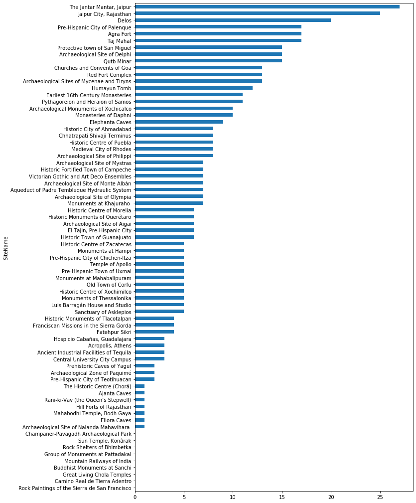

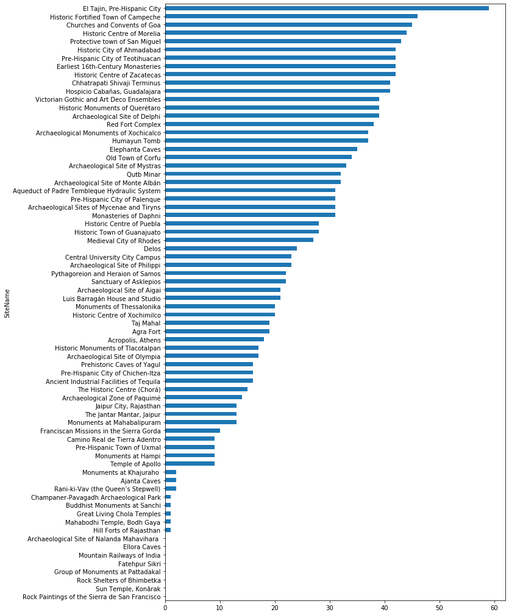

**Transportation - This was an interesting observation. Quite a few sites which offer transportation in its vicinity while Food and accommodation were not available based on the data I acquired. It seems that sites having transportation is in remote area while all other sites have their transportation facility which falls beyond my radius consideration. For example Acropolis, Athens does show any transportation facility which is very unlikely. On the other hand Taj Mahal, India is situated in a comparatively smaller city therefore mode of transports are found within my radius consideration.**

### May be I should consider collecting transportation data separately, noting if accessible or not

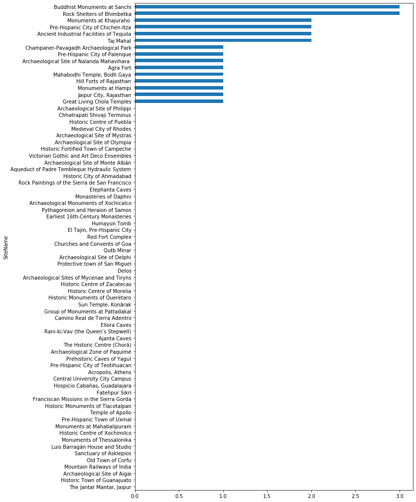

**Historic Sites - Out of 72 only 16 sites don't offer any other historic sites in the vicinity**

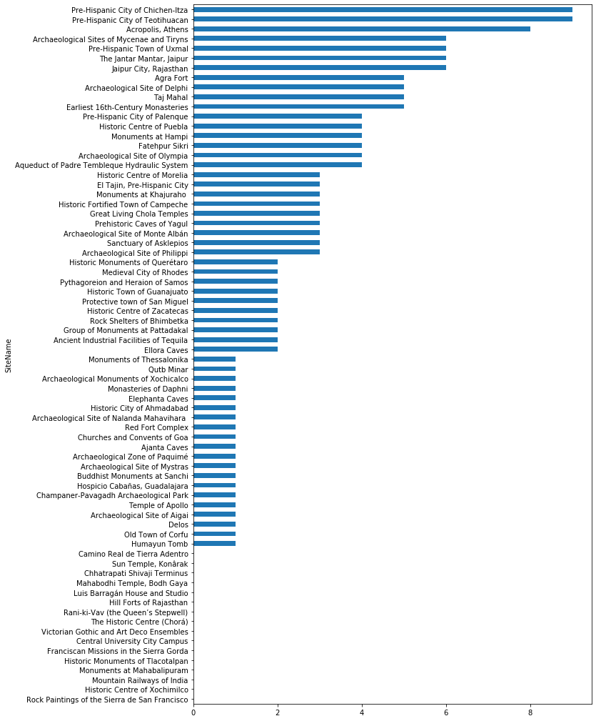

**Beach - Out of 72 only 18 sites are close to ocean, mostly in Greece and a few in India**

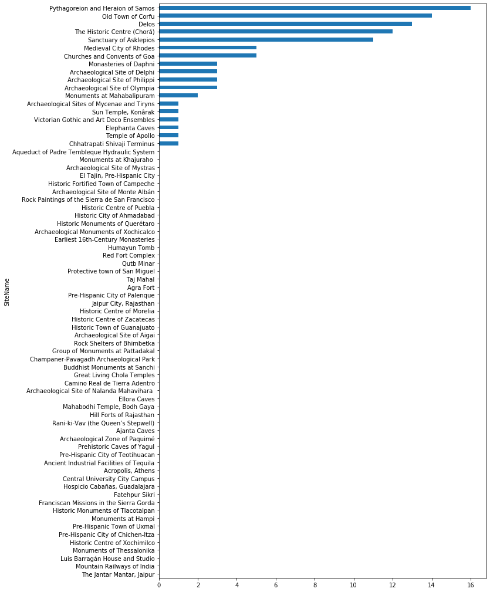

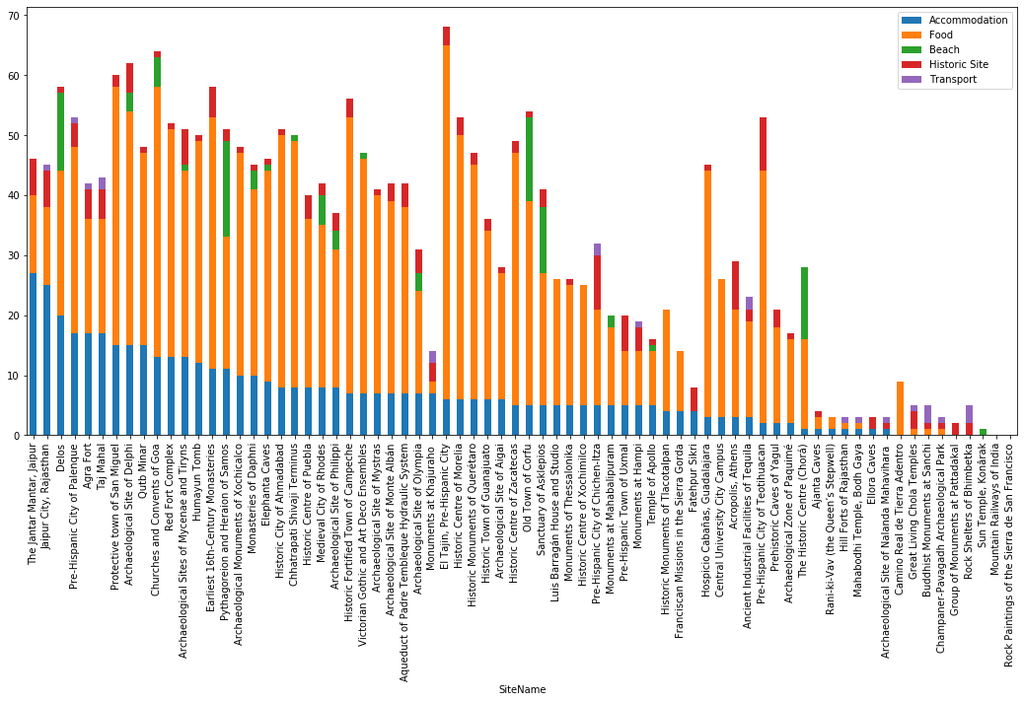

**Let's observe distribution of basic amenities using a box-plot**

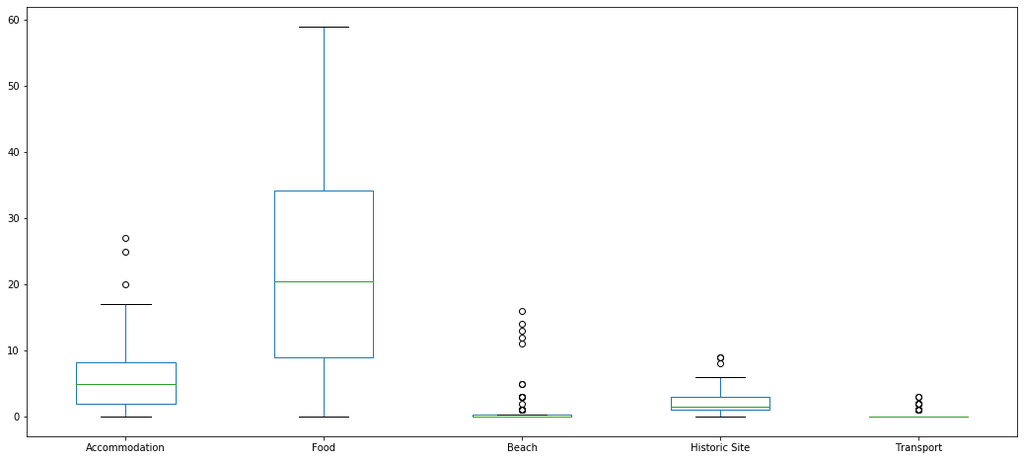

```
Following is a list of underdeveloped sites across the data set -
```

|  | country | name | built-in | ATM | Accommodation | Bank | Beach | Café | Castle | Clothing Store | Dessert Shop | Drink | Food | General Travel | Hindu Temple | Historic Site | Memorial Site | Mobile Phone Shop | Motorcycle Shop | Mountain | Museum | Nature Preserve | River | Scenic Lookout | Sculpture Garden | Ski Area | Spa | Spiritual Center | Temple | … |
| --- | --- | --- | --- | --- | --- | --- | --- | --- | --- | --- | --- | --- | --- | --- | --- | --- | --- | --- | --- | --- | --- | --- | --- | --- | --- | --- | --- | --- | --- | --- |
| 0 | Mexico | Rock Paintings of the Sierra de San Francisco | 1st Century BC | 0 | 0 | 0 | 0 | 0 | 0 | 0 | 0 | 0 | 0 | 0 | 0 | 0 | 0 | 0 | 0 | 0 | 0 | 1 | 0 | 1 | 0 | 0 | 0 | 0 | 0 | … |
| 1 | India | Ellora Caves | 7th Century | 0 | 1 | 0 | 0 | 0 | 1 | 0 | 0 | 0 | 0 | 0 | 0 | 2 | 0 | 0 | 0 | 0 | 0 | 0 | 0 | 0 | 0 | 0 | 0 | 0 | 0 | … |
| 2 | India | Sun Temple, Konârak | 13th Century | 2 | 0 | 0 | 1 | 0 | 0 | 0 | 0 | 0 | 0 | 0 | 1 | 0 | 0 | 0 | 0 | 0 | 0 | 0 | 0 | 0 | 0 | 0 | 0 | 0 | 0 | … |
| 3 | India | Hill Forts of Rajasthan | 7th Century | 0 | 1 | 0 | 0 | 0 | 0 | 0 | 0 | 0 | 1 | 0 | 0 | 0 | 0 | 0 | 0 | 0 | 0 | 0 | 0 | 0 | 0 | 0 | 0 | 0 | 0 | … |
| 4 | India | Mountain Railways of India | 19th Century | 0 | 0 | 0 | 0 | 1 | 0 | 0 | 0 | 0 | 0 | 0 | 0 | 0 | 0 | 0 | 0 | 1 | 0 | 0 | 1 | 0 | 0 | 0 | 1 | 0 | 0 | … |
| 5 | India | Archaeological Site of Nalanda Mahavihara | 3rd Century BC | 0 | 1 | 0 | 0 | 0 | 0 | 0 | 0 | 0 | 0 | 0 | 0 | 1 | 0 | 0 | 0 | 1 | 0 | 0 | 0 | 0 | 0 | 0 | 0 | 0 | 0 | … |
| 6 | India | Champaner-Pavagadh Archaeological Park | 15th Century | 0 | 0 | 0 | 0 | 0 | 0 | 0 | 0 | 0 | 1 | 0 | 0 | 1 | 0 | 0 | 0 | 0 | 0 | 0 | 0 | 0 | 0 | 1 | 0 | 0 | 1 | … |
| 7 | India | Rani-ki-Vav (the Queen’s Stepwell) | 11th Century | 1 | 1 | 0 | 0 | 0 | 0 | 0 | 0 | 0 | 2 | 0 | 0 | 0 | 1 | 0 | 1 | 0 | 0 | 0 | 0 | 0 | 0 | 0 | 0 | 0 | 0 | … |
| 8 | India | Group of Monuments at Pattadakal | 8th Century | 0 | 0 | 0 | 0 | 0 | 0 | 0 | 0 | 1 | 0 | 0 | 0 | 2 | 0 | 0 | 0 | 0 | 1 | 0 | 0 | 1 | 2 | 0 | 0 | 0 | 0 | … |
| 9 | India | Ajanta Caves | 2nd Century BC | 2 | 1 | 0 | 0 | 0 | 0 | 0 | 0 | 0 | 2 | 0 | 0 | 1 | 0 | 1 | 0 | 0 | 0 | 0 | 0 | 0 | 0 | 0 | 0 | 0 | 0 | … |
| 10 | India | Great Living Chola Temples | 11th Century | 0 | 0 | 0 | 0 | 0 | 0 | 1 | 0 | 0 | 1 | 0 | 0 | 3 | 0 | 0 | 0 | 0 | 1 | 0 | 0 | 0 | 0 | 0 | 0 | 0 | 0 | … |
| 11 | India | Buddhist Monuments at Sanchi | 3rd Century BC | 0 | 0 | 1 | 0 | 0 | 0 | 0 | 1 | 0 | 1 | 0 | 0 | 1 | 0 | 0 | 0 | 0 | 0 | 0 | 0 | 0 | 0 | 0 | 0 | 0 | 0 | … |
| 12 | India | Mahabodhi Temple, Bodh Gaya | 5th Century | 0 | 1 | 0 | 0 | 1 | 0 | 0 | 0 | 0 | 1 | 0 | 0 | 0 | 0 | 0 | 0 | 0 | 0 | 0 | 0 | 0 | 0 | 0 | 0 | 1 | 1 | … |
| 13 | India | Rock Shelters of Bhimbetka | Late Pleistocene | 1 | 0 | 0 | 0 | 0 | 0 | 0 | 0 | 0 | 0 | 1 | 0 | 2 | 0 | 0 | 0 | 1 | 0 | 0 | 0 | 1 | 0 | 0 | 0 | 0 | 0 | … |

#### It is evident from the data above that in Mexico and India there are some sites which don't have basic amenities such as a place to stay.

### Model Development

I am planning to create clusters based on top 5 features, however, some sites don't even have 5 amenities in total (based on Foursquare)

Based on external research it was observed that out of these sites some of them are pretty significant, hence, there is a lot of opportunity to develop site itself or guided tour opportunity as well.

Get the mean numbers of each feature per site so that their weight is uniform across the board and hence results are not biased List of all sites with 5 most common features

|  | SiteName | 1st Most Common Venue | 2nd Most Common Venue | 3rd Most Common Venue | 4th Most Common Venue | 5th Most Common Venue |
| --- | --- | --- | --- | --- | --- | --- |
| 0 | Acropolis, Athens | Café | Food | Drink | Historic Site | Museum |
| 1 | Agra Fort | Food | Accommodation | Historic Site | Café | Transport |
| 2 | Ajanta Caves | ATM | Food | Accommodation | Mobile Phone Shop | Historic Site |
| 3 | Ancient Industrial Facilities of Tequila | Food | Drink | Museum | Accommodation | Plaza |
| 4 | Aqueduct of Padre Tembleque Hydraulic System | Food | Accommodation | Plaza | Convenience Store | Historic Site |
| 5 | Archaeological Monuments of Xochicalco | Food | Accommodation | Garden | Sport Center | Dessert Shop |
| 6 | Archaeological Site of Aigai | Food | Café | Accommodation | Drink | Cupcake Shop |
| 7 | Archaeological Site of Delphi | Food | Accommodation | Café | Drink | Historic Site |
| 8 | Archaeological Site of Monte Albán | Food | Drink | Café | Accommodation | Dessert Shop |
| 9 | Archaeological Site of Mystras | Food | Café | Accommodation | Drink | Plaza |
| 10 | Archaeological Site of Nalanda Mahavihara | Transport | Accommodation | Historic Site | Mountain | Zoo |
| 11 | Archaeological Site of Olympia | Food | Café | Accommodation | Historic Site | Drink |
| 12 | Archaeological Site of Philippi | Food | Café | Accommodation | Drink | Supermarket |
| 13 | Archaeological Sites of Mycenae and Tiryns | Food | Accommodation | Café | Dessert Shop | Historic Site |
| 14 | Archaeological Zone of Paquimé | Food | Accommodation | Department Store | Convenience Store | Museum |
| 15 | Buddhist Monuments at Sanchi | Transport | Food | Dessert Shop | Historic Site | Bank |
| 16 | Camino Real de Tierra Adentro | Food | Farm | Mountain | Business Service | Racetrack |
| 17 | Central University City Campus | Food | Dessert Shop | Park | Café | Theme Park Ride / Attraction |
| 18 | Champaner-Pavagadh Archaeological Park | Food | Transport | Temple | Ski Area | Historic Site |
| 19 | Chhatrapati Shivaji Terminus | Food | Café | Drink | Accommodation | Dessert Shop |
| 20 | Churches and Convents of Goa | Food | Accommodation | Drink | Café | Beach |
| 21 | Delos | Food | Accommodation | Drink | Beach | Café |
| 22 | Earliest 16th-Century Monasteries | Food | Accommodation | Drink | Historic Site | Dessert Shop |
| 23 | El Tajin, Pre-Hispanic City | Food | Accommodation | Dessert Shop | Historic Site | Drink |
| 24 | Elephanta Caves | Food | Café | Accommodation | Drink | Dessert Shop |
| 25 | Ellora Caves | Historic Site | Accommodation | Castle | Zoo | Electronics Store |
| 26 | Fatehpur Sikri | Accommodation | Historic Site | Sculpture Garden | Border Crossing | Park |
| 27 | Franciscan Missions in the Sierra Gorda | Food | Accommodation | Scenic Lookout | Mountain | Plaza |
| 28 | Great Living Chola Temples | Historic Site | Transport | Food | Clothing Store | Museum |
| 29 | Group of Monuments at Pattadakal | Sculpture Garden | Historic Site | Scenic Lookout | Drink | Museum |
| 30 | Hill Forts of Rajasthan | Transport | Accommodation | Food | Trail | Zoo |
| 31 | Historic Centre of Morelia | Food | Dessert Shop | Accommodation | Drink | Café |
| 32 | Historic Centre of Puebla | Food | Accommodation | Dessert Shop | Café | Drink |
| 33 | Historic Centre of Xochimilco | Food | Museum | Dessert Shop | Café | Accommodation |
| 34 | Historic Centre of Zacatecas | Food | Drink | Café | Museum | Accommodation |
| 35 | Historic City of Ahmadabad | Food | Café | Dessert Shop | Accommodation | Tea Room |
| 36 | Historic Fortified Town of Campeche | Food | Café | Accommodation | Drink | Museum |
| 37 | Historic Monuments of Querétaro | Food | Dessert Shop | Drink | Plaza | Accommodation |
| 38 | Historic Monuments of Tlacotalpan | Food | Accommodation | Drink | Department Store | Park |
| 39 | Historic Town of Guanajuato | Food | Drink | Café | Plaza | Accommodation |
| 40 | Hospicio Cabañas, Guadalajara | Food | Dessert Shop | Café | Drink | Accommodation |
| 41 | Humayun Tomb | Food | Café | Accommodation | Dessert Shop | Museum |
| 42 | Jaipur City, Rajasthan | Accommodation | Food | Historic Site | Drink | Dessert Shop |
| 43 | Luis Barragán House and Studio | Food | Dessert Shop | Museum | Drink | Accommodation |
| 44 | Mahabodhi Temple, Bodh Gaya | Accommodation | Food | Café | Town | Spiritual Center |
| 45 | Medieval City of Rhodes | Food | Dessert Shop | Café | Drink | Accommodation |
| 46 | Monasteries of Daphni | Food | Café | Accommodation | Drink | Supermarket |
| 47 | Monuments at Hampi | Food | Accommodation | Historic Site | Drink | Transport |
| 48 | Monuments at Khajuraho | Accommodation | Historic Site | Transport | Food | Zoo |
| 49 | Monuments at Mahabalipuram | Food | Accommodation | Beach | Café | Zoo |
| 50 | Monuments of Thessalonika | Food | Drink | Café | Dessert Shop | Accommodation |
| 51 | Mountain Railways of India | River | Mountain | Café | Spa | Food |
| 52 | Old Town of Corfu | Food | Beach | Café | Drink | Dessert Shop |
| 53 | Pre-Hispanic City of Chichen-Itza | Food | Historic Site | Accommodation | Lake | Café |
| 54 | Pre-Hispanic City of Palenque | Food | Accommodation | Café | Historic Site | Nature Preserve |
| 55 | Pre-Hispanic City of Teotihuacan | Food | Historic Site | Museum | Dessert Shop | Plaza |
| 56 | Pre-Hispanic Town of Uxmal | Food | Historic Site | Accommodation | Museum | National Park |
| 57 | Prehistoric Caves of Yagul | Food | Historic Site | Dessert Shop | Café | Accommodation |
| 58 | Protective town of San Miguel | Food | Accommodation | Café | Dessert Shop | Drink |
| 59 | Pythagoreion and Heraion of Samos | Food | Drink | Beach | Accommodation | Café |
| 60 | Qutb Minar | Food | Café | Accommodation | Drink | Dessert Shop |
| 61 | Rani-ki-Vav (the Queen’s Stepwell) | Food | ATM | Memorial Site | Motorcycle Shop | Accommodation |
| 62 | Red Fort Complex | Food | Café | Accommodation | Drink | Museum |
| 63 | Rock Paintings of the Sierra de San Francisco | Scenic Lookout | Nature Preserve | Zoo | Drink | Forest |
| 64 | Rock Shelters of Bhimbetka | Transport | Historic Site | ATM | General Travel | Mountain |
| 65 | Sanctuary of Asklepios | Food | Beach | Café | Drink | Accommodation |
| 66 | Sun Temple, Konârak | ATM | Hindu Temple | Beach | Electronics Store | Fountain |
| 67 | Taj Mahal | Food | Accommodation | Historic Site | Café | Transport |
| 68 | Temple of Apollo | Food | Café | Accommodation | Waterfall | Historic Site |
| 69 | The Historic Centre (Chorá) | Food | Beach | Café | Drink | Dessert Shop |
| 70 | The Jantar Mantar, Jaipur | Accommodation | Food | Historic Site | Café | Dessert Shop |
| 71 | Victorian Gothic and Art Deco Ensembles | Food | Café | Drink | Accommodation | Dessert Shop |

Now prepared data will be used to fit using K-Means Clustering (Unsupervised Machine Learning) algorithm to find clusters of sites.

[interactive chart not shown]

My model creates following 6 clusters.

**Cluster 1 - City Setup with many other sites of historic importance**

|  | country | name | built-in | 1st Most Common Venue | 2nd Most Common Venue | 3rd Most Common Venue | 4th Most Common Venue | 5th Most Common Venue |
| --- | --- | --- | --- | --- | --- | --- | --- | --- |
| 0 | India | Monuments at Khajuraho | 10th Century | Accommodation | Historic Site | Transport | Food | Zoo |
| 1 | India | Ajanta Caves | 2nd Century BC | ATM | Food | Accommodation | Mobile Phone Shop | Historic Site |
| 2 | India | Ellora Caves | 7th Century | Historic Site | Accommodation | Castle | Zoo | Electronics Store |
| 3 | India | Hill Forts of Rajasthan | 7th Century | Transport | Accommodation | Food | Trail | Zoo |
| 4 | India | Agra Fort | 17th Century | Food | Accommodation | Historic Site | Café | Transport |
| 5 | India | Taj Mahal | 17th Century | Food | Accommodation | Historic Site | Café | Transport |
| 6 | India | Fatehpur Sikri | 16th Century | Accommodation | Historic Site | Sculpture Garden | Border Crossing | Park |
| 7 | India | The Jantar Mantar, Jaipur | 18th Century | Accommodation | Food | Historic Site | Café | Dessert Shop |
| 8 | India | Archaeological Site of Nalanda Mahavihara | 3rd Century BC | Transport | Accommodation | Historic Site | Mountain | Zoo |
| 9 | India | Jaipur City, Rajasthan | 18th Century | Accommodation | Food | Historic Site | Drink | Dessert Shop |
| 10 | Mexico | Pre-Hispanic Town of Uxmal | 8th Century | Food | Historic Site | Accommodation | Museum | National Park |

**Cluster 2 - Urban setup with variety of activities**

|  | country | name | built-in | 1st Most Common Venue | 2nd Most Common Venue | 3rd Most Common Venue | 4th Most Common Venue | 5th Most Common Venue |
| --- | --- | --- | --- | --- | --- | --- | --- | --- |
| 0 | Greece | Temple of Apollo | 5th Century BC | Food | Café | Accommodation | Waterfall | Historic Site |
| 1 | Greece | Acropolis, Athens | 5th Century BC | Café | Food | Drink | Historic Site | Museum |
| 2 | Greece | Monuments of Thessalonika | 4th Century BC | Food | Drink | Café | Dessert Shop | Accommodation |
| 3 | Greece | Sanctuary of Asklepios | 4th Century BC | Food | Beach | Café | Drink | Accommodation |
| 4 | Greece | Medieval City of Rhodes | 14th Century | Food | Dessert Shop | Café | Drink | Accommodation |
| 5 | Greece | Archaeological Site of Olympia | 8th Century BC | Food | Café | Accommodation | Historic Site | Drink |
| 6 | Greece | Delos | 7th Century BC | Food | Accommodation | Drink | Beach | Café |
| 7 | Greece | Monasteries of Daphni | 11th Century | Food | Café | Accommodation | Drink | Supermarket |
| 8 | Greece | Pythagoreion and Heraion of Samos | 6th Century BC | Food | Drink | Beach | Accommodation | Café |
| 9 | Greece | Archaeological Sites of Mycenae and Tiryns | 2nd Millenium BC | Food | Accommodation | Café | Dessert Shop | Historic Site |
| 10 | Greece | The Historic Centre (Chorá) | 11th Century | Food | Beach | Café | Drink | Dessert Shop |
| 11 | Greece | Old Town of Corfu | 15th Century | Food | Beach | Café | Drink | Dessert Shop |
| 12 | Greece | Archaeological Site of Philippi | 4th Century BC | Food | Café | Accommodation | Drink | Supermarket |
| 13 | India | Qutb Minar | 13th Century | Food | Café | Accommodation | Drink | Dessert Shop |
| 14 | India | Mountain Railways of India | 19th Century | River | Mountain | Café | Spa | Food |
| 15 | India | Mahabodhi Temple, Bodh Gaya | 5th Century | Accommodation | Food | Café | Town | Spiritual Center |
| 16 | Mexico | Historic Centre of Xochimilco | 16th Century | Food | Museum | Dessert Shop | Café | Accommodation |
| 17 | Mexico | Archaeological Site of Monte Albán | 3rd Century | Food | Drink | Café | Accommodation | Dessert Shop |
| 18 | Mexico | Historic Centre of Puebla | 16th Century | Food | Accommodation | Dessert Shop | Café | Drink |
| 19 | Mexico | Historic Town of Guanajuato | 18th Century | Food | Drink | Café | Plaza | Accommodation |
| 20 | Mexico | Luis Barragán House and Studio | 20th Century | Food | Dessert Shop | Museum | Drink | Accommodation |
| 21 | Mexico | Ancient Industrial Facilities of Tequila | 19th Century | Food | Drink | Museum | Accommodation | Plaza |
| 22 | Mexico | Central University City Campus | 20th Century | Food | Dessert Shop | Park | Café | Theme Park Ride / Attraction |

**Cluster 3 - Remote and not much to do**

|  | country | name | built-in | 1st Most Common Venue | 2nd Most Common Venue | 3rd Most Common Venue | 4th Most Common Venue | 5th Most Common Venue |
| --- | --- | --- | --- | --- | --- | --- | --- | --- |
| 0 | India | Sun Temple, Konârak | 13th Century | ATM | Hindu Temple | Beach | Electronics Store | Fountain |

**Cluster 4 - Urban Setup**

|  | country | name | built-in | 1st Most Common Venue | 2nd Most Common Venue | 3rd Most Common Venue | 4th Most Common Venue | 5th Most Common Venue |
| --- | --- | --- | --- | --- | --- | --- | --- | --- |
| 0 | Greece | Archaeological Site of Delphi | 6th Century BC | Food | Accommodation | Café | Drink | Historic Site |
| 1 | Greece | Archaeological Site of Mystras | 13th Century | Food | Café | Accommodation | Drink | Plaza |
| 2 | Greece | Archaeological Site of Aigai | 4th Century BC | Food | Café | Accommodation | Drink | Cupcake Shop |
| 3 | India | Red Fort Complex | 17th Century | Food | Café | Accommodation | Drink | Museum |
| 4 | India | Humayun Tomb | 16th Century | Food | Café | Accommodation | Dessert Shop | Museum |
| 5 | India | Churches and Convents of Goa | 16th Century | Food | Accommodation | Drink | Café | Beach |
| 6 | India | Monuments at Hampi | 16th Century | Food | Accommodation | Historic Site | Drink | Transport |
| 7 | India | Elephanta Caves | 6th Century | Food | Café | Accommodation | Drink | Dessert Shop |
| 8 | India | Monuments at Mahabalipuram | 7th Century | Food | Accommodation | Beach | Café | Zoo |
| 9 | India | Rani-ki-Vav (the Queen’s Stepwell) | 11th Century | Food | ATM | Memorial Site | Motorcycle Shop | Accommodation |
| 10 | India | Chhatrapati Shivaji Terminus | 19th Century | Food | Café | Drink | Accommodation | Dessert Shop |
| 11 | India | Victorian Gothic and Art Deco Ensembles | 19th Century | Food | Café | Drink | Accommodation | Dessert Shop |
| 12 | India | Historic City of Ahmadabad | 15th Century | Food | Café | Dessert Shop | Accommodation | Tea Room |
| 13 | Mexico | Pre-Hispanic City of Palenque | 6th Century | Food | Accommodation | Café | Historic Site | Nature Preserve |
| 14 | Mexico | Pre-Hispanic City of Teotihuacan | 1st Century | Food | Historic Site | Museum | Dessert Shop | Plaza |
| 15 | Mexico | Pre-Hispanic City of Chichen-Itza | 10th Century | Food | Historic Site | Accommodation | Lake | Café |
| 16 | Mexico | Archaeological Zone of Paquimé | 12th Century | Food | Accommodation | Department Store | Convenience Store | Museum |
| 17 | Mexico | Historic Centre of Morelia | 16th Century | Food | Dessert Shop | Accommodation | Drink | Café |
| 18 | Mexico | El Tajin, Pre-Hispanic City | 9th Century | Food | Accommodation | Dessert Shop | Historic Site | Drink |
| 19 | Mexico | Historic Centre of Zacatecas | 16th Century | Food | Drink | Café | Museum | Accommodation |
| 20 | Mexico | Earliest 16th-Century Monasteries | 16th Century | Food | Accommodation | Drink | Historic Site | Dessert Shop |
| 21 | Mexico | Historic Monuments of Querétaro | 17th Century | Food | Dessert Shop | Drink | Plaza | Accommodation |
| 22 | Mexico | Hospicio Cabañas, Guadalajara | 19th Century | Food | Dessert Shop | Café | Drink | Accommodation |
| 23 | Mexico | Historic Monuments of Tlacotalpan | 19th Century | Food | Accommodation | Drink | Department Store | Park |
| 24 | Mexico | Historic Fortified Town of Campeche | 17th Century | Food | Café | Accommodation | Drink | Museum |
| 25 | Mexico | Archaeological Monuments of Xochicalco | 7th Century | Food | Accommodation | Garden | Sport Center | Dessert Shop |
| 26 | Mexico | Franciscan Missions in the Sierra Gorda | 17th Century | Food | Accommodation | Scenic Lookout | Mountain | Plaza |
| 27 | Mexico | Protective town of San Miguel | 18th Century | Food | Accommodation | Café | Dessert Shop | Drink |
| 28 | Mexico | Camino Real de Tierra Adentro | 16th Century | Food | Farm | Mountain | Business Service | Racetrack |
| 29 | Mexico | Prehistoric Caves of Yagul | 9th Millenium BC | Food | Historic Site | Dessert Shop | Café | Accommodation |
| 30 | Mexico | Aqueduct of Padre Tembleque Hydraulic System | 16th Century | Food | Accommodation | Plaza | Convenience Store | Historic Site |

**Cluster 5 - Remote but connected with many other historic sites**

|  | country | name | built-in | 1st Most Common Venue | 2nd Most Common Venue | 3rd Most Common Venue | 4th Most Common Venue | 5th Most Common Venue |
| --- | --- | --- | --- | --- | --- | --- | --- | --- |
| 0 | India | Group of Monuments at Pattadakal | 8th Century | Sculpture Garden | Historic Site | Scenic Lookout | Drink | Museum |
| 1 | India | Great Living Chola Temples | 11th Century | Historic Site | Transport | Food | Clothing Store | Museum |
| 2 | India | Buddhist Monuments at Sanchi | 3rd Century BC | Transport | Food | Dessert Shop | Historic Site | Bank |
| 3 | India | Rock Shelters of Bhimbetka | Late Pleistocene | Transport | Historic Site | ATM | General Travel | Mountain |
| 4 | India | Champaner-Pavagadh Archaeological Park | 15th Century | Food | Transport | Temple | Ski Area | Historic Site |

**Cluster 6 - Isolated**

|  | country | name | built-in | 1st Most Common Venue | 2nd Most Common Venue | 3rd Most Common Venue | 4th Most Common Venue | 5th Most Common Venue |
| --- | --- | --- | --- | --- | --- | --- | --- | --- |
| 0 | Mexico | Rock Paintings of the Sierra de San Francisco | 1st Century BC | Scenic Lookout | Nature Preserve | Zoo | Drink | Forest |

## Results and Discussion

Results of analysis using K-Means clustering algorithm using k-factor as 6 has split the data set into following 6 categories -

1. Urban Setup (Comfortable for Tourists)
2. City Setup (Easily Doable)
3. Urban Setup with more to do for tourists (Economical)
4. Isolated Site (Adventurous)
5. Remote but Connected
6. Remote Site and not much to do

This analysis shows that algorithm is working fine and can be used as a reference by tourists and tour operators to plan. I feel some data about the popularity of the sites based on foot-fall or more social-media data about these sites will enhance the quality of the results.

## Conclusion

Purpose of the project was to develop a model which will categorize a world heritage site in one of the six clusters discussed in "Result and Discussion" section of this report. Categorization model will help tourists to plan their upcoming trip in a more personalized way by knowing ahead of time, what they are signing up. At the same time stakeholders can also use this report to plan their offering.

Using basic categorization users of this report can further fine tune their trip based on the additional research done about the country and the area they are planning to visit.

From system's perspective I will be working further to enhance dataset using more popularity and social media data to fine tune this model. It was evident while analyzing the data some of the remote sites may not be having enough data as not many people may have reported it to Foursquare.